# Wed Sep 17

# Agenda

- Entrance Ticket
  - [ET_09_17](https://bart.instructure.com/courses/2110/quizzes/3178)
- Discuss exam scores
- Find a solution to a transformed function when given a corresponding point on $y=f(x)$.
  - [Practice Problems](https://chadworley.github.io/algtwo2026/u02/09_17/outhtml/01_use_fsol_find_gsol.html)
  - [Paper Practice](https://chadworley.github.io/algtwo2026/u02/09_17/practice_solve_eq_w_func.pdf)
  - [OCW_09_17_solve_eq_with_func](https://bart.instructure.com/courses/2110/quizzes/3179)

# Exam scores

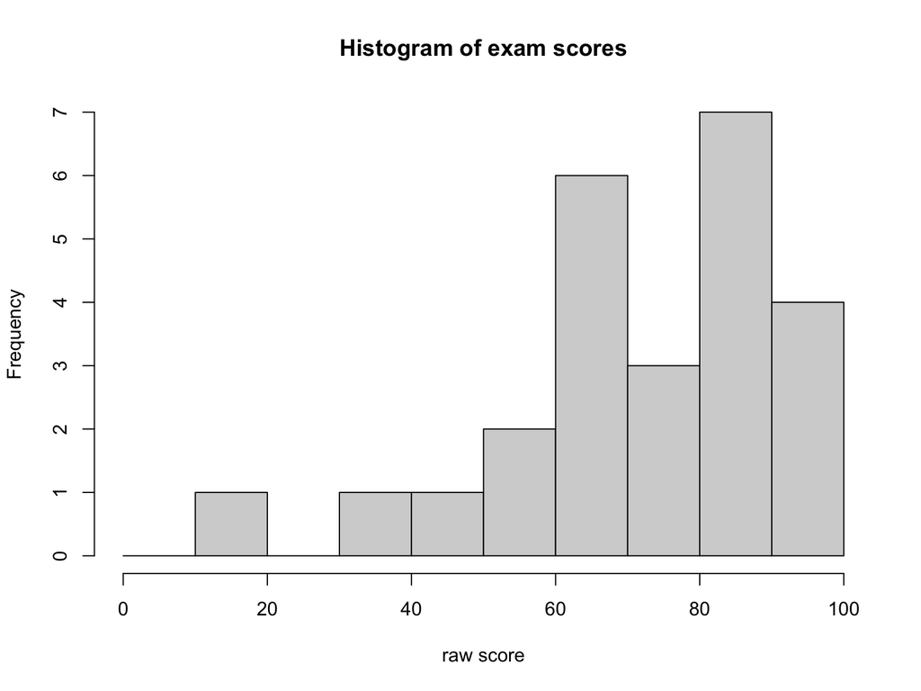

- The test was difficult, and people did quite well.
- I feel a “curve” is warranted.
- Really, it is more of a “50 is the floor” system. If $x$ is the raw score (what is written on your test), you can calculate your mastery score ($y$) using the formula below:
  $$y=50+\frac{x}{2}$$

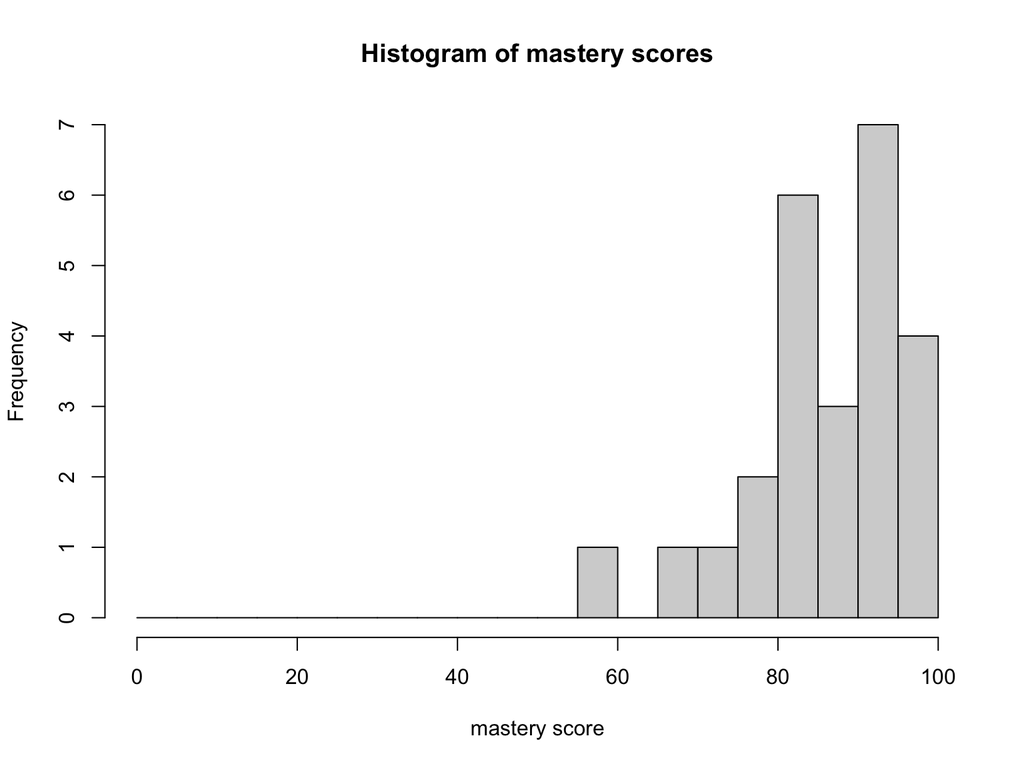

# Upcoming topics for Q1

- Function translations
- Function stretches
- Parent functions
- Combining reflections, translations, and stretches with parent functions
- Function descriptions
  - Domain/range
  - Intervals of increase/descrease
  - Intervals of positivity/negativity
  - End behavior
  - Intercepts
  - Extrema (minima and maxima)

# Problem 1

If $f(8)=10$ then we can find a solution to the equation below:

$$y=\frac{f(3x-7)}{5}+4$$

Find the knowable solution.

- $x=$ ?
- $y=$ ?

### Solution

1. Set the argument equal to 8.
   $$3x-7=8$$
   $$3x=15$$
   $$x=5$$
2. Substitute 5 for $x$.
   $$y=\frac{f(3\cdot5-7)}{5}+4$$
3. Simplify the argument.
   $$y=\frac{f(15-7)}{5}+4$$
   $$y=\frac{f(8)}{5}+4$$
4. Substitute 10 for $f(8)$.
   $$y=\frac{10}{5}+4$$
   $$y=2+4$$
   $$y=6$$

So the solution is $(5,6)$, which can be written as two equations: $x=5$ and $y=6$.

# Problem 2

If $f[9]=6$ then we can find a solution to the equation below:

$$y= 4\cdot
f{\left[\frac{x+5}{2}\right]}-1$$

Find the knowable solution.

- $x=$ ?
- $y=$ ?

### Solution

1. Set the argument equal to 9.
   $$\frac{x+5}{2}=9$$
   $$x+5=18$$
   $$x=13$$
2. Substitute 13 for $x$.
   $$y= 4\cdot
   f{\left[\frac{13+5}{2}\right]}-1$$
3. Simplify the argument.
   $$y= 4\cdot
   f{\left[\frac{18}{2}\right]}-1$$
   $$y=
   4\cdot f{\left[9\right]}-1$$
4. Substitute 6 for $f[9]$.
   $$y= 4\cdot 6-1$$
   $$y=24-1$$
   $$y=23$$

So the solution is $(13,23)$, which can be written as two equations: $x=13$ and $y=23$.

# Problem 3

If $f[8]=36$ then we can find a solution to the equation below:

$$y= \frac{1}{4} \cdot
f{\left[\frac{x}{2}+5\right]}+22$$

Find the knowable solution.

- $x=$ ?
- $y=$ ?

### Solution

1. Set the argument equal to 8.
   $$\frac{x}{2}+5=8$$
   $$\frac{x}{2}=3$$
   $$x=6$$
2. Substitute 6 for $x$.
   $$y= \frac{1}{4} \cdot
   f{\left[\frac{6}{2}+5\right]}+22$$
3. Simplify the argument.
   $$y=
   \frac{1}{4} \cdot f{\left[3+5\right]}+22$$
   $$y= \frac{1}{4} \cdot
   f{\left[8\right]}+22$$
4. Substitute 36 for $f[8]$.
   $$y= \frac{1}{4} \cdot 36+22$$
   $$y=9+22$$
   $$y=31$$

So the solution is $(6,31)$, which can be written as two equations: $x=6$ and $y=31$.